# Probability distributions

## The Gamma Poisson distribution in R

The Gamma Poisson distribution goes by two names: “Gamma Poisson” or “negative binomial”. In R, its suffix is `nbinom.` To make things more confusing, the Gamma Poisson can be parametrized in different ways. This means, it is possible to describe the same distribution with different combinations of parameters.

In the (video lecture)[https://shiny-portal.embl.de/shinyapps/app/03_csda_tutorial_2], I introduced a parametrization with

- mean μ (the average Poisson rate) and
- scale θ (a measure for how much the Poisson rate varies between individual counts),

because I find it most intuitive. The argument `mu` in `dnbinom` lets you define μ. The argument `size` is the inverse of θ, that is for a small size you will get a distribution with a large overdispersion (=spread). For very large values of `size`, the distribution will tend towards a Poisson distribution.

Note: Consult the “Details” in the help function (`help(dnbinom)`) if you choose to parametrize in a different way.

**Exercise:** To demonstrate how the Gamma Poisson distribution differs from a Poisson, let’s compare the means and variances.

**Poisson mean:** Simulate 100 random frog counts with a Poisson rate of 4 then calculate the mean:

```r
rpois(n=100, lambda = 4) %>%
  mean()
```

```
[1] 4.25
```

**Poisson variance:** Simulate 100 random frog counts with a Poisson rate of 4, then calculate the variance using the function **var**:

```r
rpois(n=100, lambda = 4) %>%
  var()
```

```
[1] 4.071111
```

**Gamma Poisson mean:** Simulate 100 random frog counts from different lakes with a mean 4 and size=2, then calculate the mean:

```r
rnbinom(n=100, mu=4, size=2) %>%
  mean()
```

```
[1] 3.43
```

**Gamma Poisson variance:** Simulate 100 random frog counts from different lakes with a mean of 4 and size=2, then calculate the variance using the function var:

```r
rnbinom(n=100, mu=4, size=2) %>%
  var()
```

```
[1] 10.7196
```

## The Gaussian distribution

We covered the Gaussian – also known as Normal distribution earlier in this tutorial as an example, and you have most likely come across it before.

It is applicable to repeated measurements of the same thing, for example

- frog lengths,
- temperatures or
- pixel intensities.

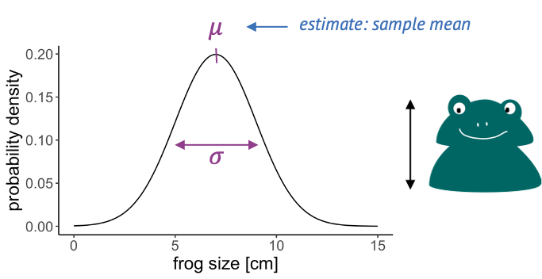

The Gaussian distribution is continuous and has two parameters:

- the mean, which is estimated by the sample mean, and
- the variance, which is estimated by the sample variance.

## Tools for visually comparing distributions

Usually, we have some data and want to find the “right” distribution for it. That means, we want to find a distribution that models the data in a suitable way. The workflow should look something like this:

1. Fit your data to a distribution that you consider plausible. We’ll see how to do this in R. The fit will give you the best parameters for this distribution, given your data.
2. Visually compare the theory to your data points. The theory in this case is the fit you just obtained. In the visualization, a good fit doesn’t show systematic deviations of the data points from theory.
3. Do the same with other plausible distributions.
4. Decide which fit looks best to you.

### A note on fitting

When we say we “fit” a distribution, we are usually talking about the maximum likelihood approach. This means we find the parameters for which it is most likely to see the given data. This is an optimization problem - and thus can be solved conveniently by the computer. You might also hear people say they minimize the deviance when they fit data, and this is just another term for minimizing the distance between the line (theory) and the points (data). The exact mathematical formula for the deviance to be minimized depends on the type of distribution we are fitting to – for example, when fitting a Gaussian distribution, we minimize the sum of squares. But no worries: The tools for fitting that you’ll get to know in this tutorial know their formulae :)

## Histograms

For demonstration, let’s simulate frog counts and sizes with random draws from a Poisson and a Gaussian distribution. This code should by now look familiar to you:

```r
set.seed(51) # set a seed for reproducibility
frog_counts <-rpois(n = 200, lambda = 4)
frog_sizes <- rnorm(n = 200, mean = 7, sd = 2)
frog_counts_different_lakes <- rnbinom(n=200, size=2, mu=4)
```

We can then use `ggplot2` to plot histograms from the simulations. The histogram will have a shape that is specific for the distribution:

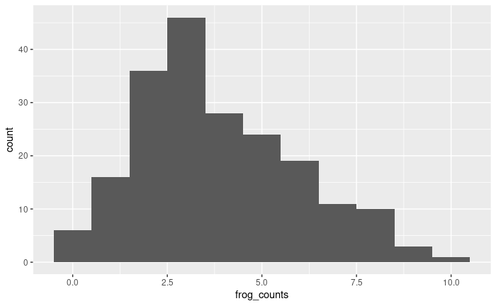

```r
data.frame(frog_counts) %>%
  ggplot(aes(x=frog_counts)) +
  geom_histogram(binwidth=1)
```

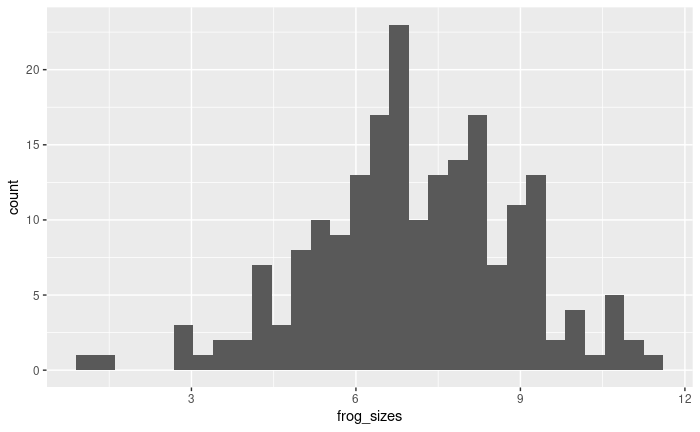

```r
data.frame(frog_sizes) %>%
  ggplot(aes(x=frog_sizes))+
  geom_histogram()
```

**Exercise:** Note how I used binwidth=1 for displaying the count data. Try what happens if you don’t:

[figure not shown]

### Relation between histogram and distribution function

The theoretical distribution gives the expected frequency of the random numbers.

For example for the Poisson frog counts, we can calculate the expected frequency of the counts from 0 to 20:

```r
counts <- 0:20
expected_freq <- dpois(counts, lambda = 4) * length(frog_counts)
```

Then we can plot the expected counts as a line on top of the histogram:

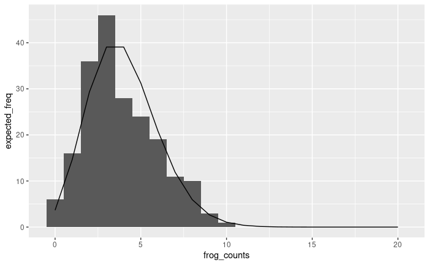